# Streamflow evaluation

# 3 Finding observations using the `RouteLink.nc` file and USGS NWIS system.

The `RouteLink.nc` file contains information about the individual feature_ids, including any associated USGS gages.

First lets bring the `RouteLink.nc` into R using a function from `rwrfhydro`

```r
#The time variable in the routelink file changes the format from a dataframe to a list
#We need to remove the time variable using the exclude argument
routeLink <- GetNcdfFile(paste0(dataPath,'/DOMAIN/RouteLink.nc'),
                         quiet=T,
                         var='time',
                         exclude = TRUE)
head(routeLink)
```

```
##   BtmWdth ChSlp Kchan Length MusK MusX NHDWaterbodyComID Qi    So     alt
## 1       2  0.05     0   3174 3600  0.2             -9999  0 0.165 3477.05
## 2       2  0.05     0   3393 3600  0.2             -9999  0 0.159 3310.87
## 3       2  0.05     0   4888 3600  0.2             -9999  0 0.113 3276.35
## 4       2  0.05     0   1542 3600  0.2             -9999  0 0.114 3259.97
## 5       2  0.05     0    425 3600  0.2             -9999  0 0.031 3383.64
## 6       2  0.05     0    219 3600  0.2             -9999  0 0.016 3384.15
##   ascendingIndex from           gages      lat    link       lon    n
## 1              9    0                 40.45488 1233907 -105.8230 0.06
## 2              0    0                 40.43501 1233913 -105.8365 0.06
## 3              7    0                 40.40122 1233941 -105.8224 0.06
## 4              1    0                 40.33501 1234455 -105.7469 0.06
## 5             15    0                 40.37445 1234611 -105.7964 0.06
## 6              2    0                 40.36185 1234615 -105.7864 0.06
##   order      to
## 1     1       0
## 2     1       0
## 3     1       0
## 4     1 1233983
## 5     1 1233961
## 6     1 1234011
```

We now have a dataframe of the `RouteLink.nc` file and can now find a gage for further analysis. Lets open the routeLink dataframe and find a feature ID with a gage on it. The routelink file does not have a feature ID field, rather it has a `link` variable which is the feature_id.

```r
#How many gages? There is only 1
unique(routeLink$gages)
```

```
## [1] "               " "402114105350101"
```

```r
#Get the gage ID
gageID <- "402114105350101"
#Get the feature ID corresponding to that gage
gageFeatureIndex <- routeLink$link[routeLink$gages == gageID]

#Subset dataframes to only features with the gage.
gage_bigTDF <- bigTDF[bigTDF$feature_id == gageFeatureIndex,]
```

Now we need to get some observations to go along with our model data. We will use the USGS R package `dataRetrieval` to do this.

```r
library(dataRetrieval)

#Limit our retrieval to the model time domain
startDate <- min(gage_bigTDF$validTime)
endDate <- max(gage_bigTDF$validTime)

#Get the instantaneous values from NWIS
obsDF <- readNWISuv(siteNumbers = gageID,
                    parameterCd = '00060',
                    startDate = startDate,
                    endDate = endDate)

#Rename the columns to more readable names
obsDF <- renameNWISColumns(obsDF)

#Convert from cfs to cms
obsDF$Flow_Inst_cms <- obsDF$Flow_Inst*0.0283
```

Now we have all our model data and our observation data. Lets plot it

# 4 Basic goodness of fit metrics

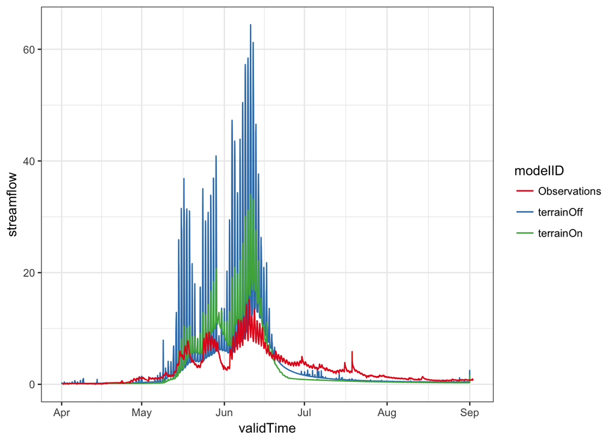

```r
#Plot it
ggplot(data = gage_bigTDF,aes(x=validTime,y=streamflow,color=modelID)) +
  geom_line() +
  geom_line(data=obsDF,aes(x=dateTime,y=Flow_Inst_cms,color='Observations')) +
  scale_color_brewer(palette="Set1") + #Add a different color scale for grins
  theme_bw()
```

We can see that the general shape is similar between the observations and the terrainOn models, but the model diurnal variations are larger. Lets compare daily means as well. For this we will introduce another package, `dplyr`

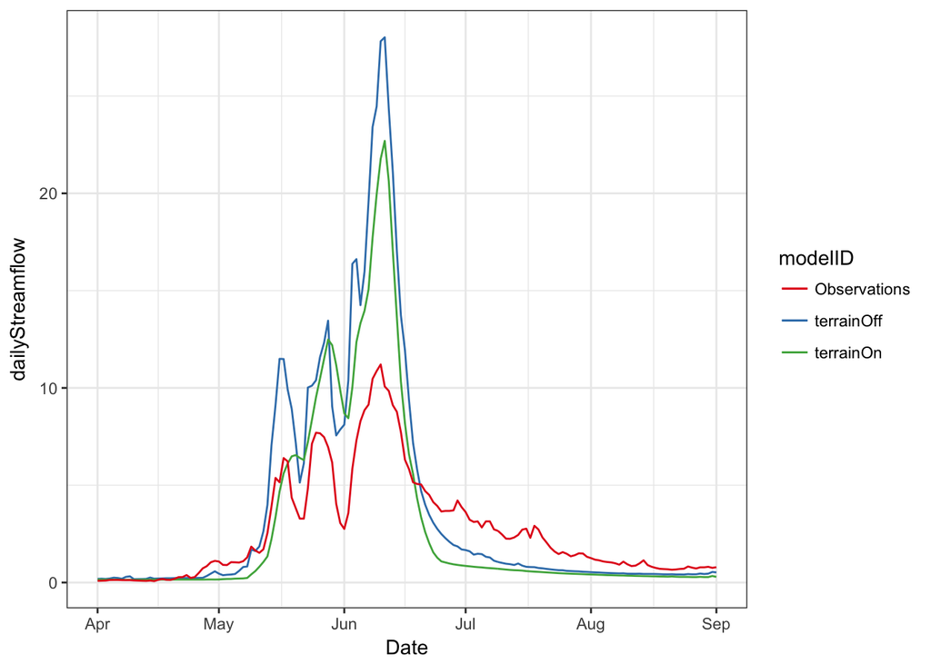

```r
library(dplyr)

#Make a new variable that is the daily date
gage_bigTDF$Date <- as.Date(gage_bigTDF$validTime)

#Group the datframe by day
gage_bigTDF_grouped <- group_by(gage_bigTDF,feature_id,modelID,Date)

#Now aggregate it to daily means
gage_bigTDF_daily <- summarize(gage_bigTDF_grouped,
                          dailyStreamflow = mean(streamflow))

#Now lets get daily obs
#Limit our retrieval to the model time domain
startDate <- min(gage_bigTDF_daily$Date)
endDate <- max(gage_bigTDF_daily$Date)

obsDF_daily <- readNWISdv(siteNumbers = gageID,
                    parameterCd = '00060',
                    startDate = startDate,
                    endDate = endDate)
obsDF_daily <- renameNWISColumns(obsDF_daily)

#Convert from cfs to cms
obsDF_daily$Flow_cms <- obsDF_daily$Flow*0.0283

#Lets plot it
ggplot(data = gage_bigTDF_daily,aes(x=Date,y=dailyStreamflow,color=modelID)) +
  geom_line() +
  geom_line(data=obsDF_daily,aes(x=Date,y=Flow_cms,color='Observations')) +
  scale_color_brewer(palette="Set1") + #Add a different color scale for grins
  theme_bw()
```

We still have a high bias in our daily mean model values for both terrain on and terrain off. Let calculate some statistics to quantify this and compare the two models to the observations. For this, we are going to use the `hydroGOF` package. A number of statistic functions are also available in `rwrfhydro`, but many of these will be added as contributions to the general `hydroGOF` package.

```r
library(dplyr)
library(hydroGOF)
#Join the observations to the modeled dataframe
joinedDF <- left_join(gage_bigTDF_daily,
                      obsDF_daily[c('Date','Flow_cms')],
                      by='Date')

#Filter to each model and calculate some stats
joinedDF_terrainOn <- joinedDF[joinedDF$modelID == 'terrainOn',]
joinedDF_terrainOff <- joinedDF[joinedDF$modelID == 'terrainOff',]

#Now calculate stats
terrainOnStats <- gof(joinedDF_terrainOn$dailyStreamflow,
                      joinedDF_terrainOn$Flow_cms)
terrainOffStats <- gof(joinedDF_terrainOff$dailyStreamflow,
                      joinedDF_terrainOff$Flow_cms)

#Print them
print(terrainOnStats)
```

```
##           [,1]
## ME        0.21
## MAE       1.79
## MSE       8.10
## RMSE      2.85
## NRMSE % 105.40
## PBIAS %   8.00
## RSR       1.05
## rSD       1.87
## NSE      -0.12
## mNSE      0.16
## rNSE      0.50
## d         0.86
## md        0.69
## rd        0.94
## cp      -26.29
## r         0.90
## R2        0.81
## bR2       0.59
## KGE       0.13
## VE        0.33
```

```r
print(terrainOffStats)
```

```
##           [,1]
## ME        1.09
## MAE       2.11
## MSE      15.22
## RMSE      3.90
## NRMSE % 144.50
## PBIAS %  40.50
## RSR       1.45
## rSD       2.27
## NSE      -1.10
## mNSE      0.01
## rNSE      0.43
## d         0.80
## md        0.65
## rd        0.95
## cp      -50.28
## r         0.93
## R2        0.86
## bR2       0.49
## KGE      -0.33
## VE        0.22
```

We were able to quantify the bias compared to the observations. We can also see an imrpovement in bias and error metrics when using terrain routing.

# 5 Flow duration curves

Here we will look at the modelled and observed streamflow values in a slightly different way using flow duration curves.

First we need to calculate flow exceedence probabilities using a function from `rwrfhydro`. Note that this type of analysis typically uses much longer periods of record to be meaningfull. This is merely a demonstration

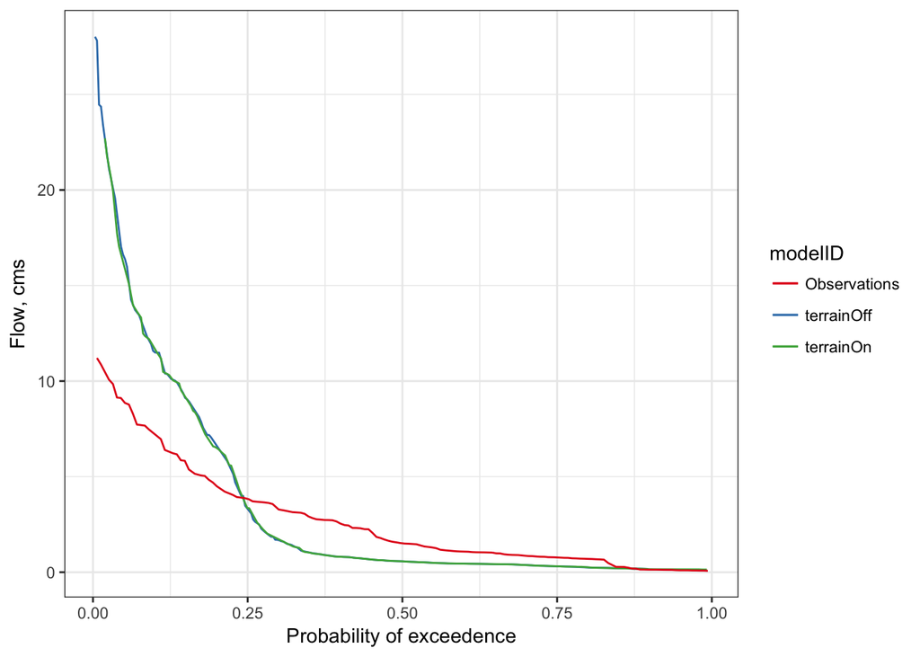

```r
#We will group our modeled datadrame again to calculate flow duration curves for each model
#Note the use of piping, a newer convention in R for shorter analysis code
gage_bigTDF_dailyFDC <- group_by(gage_bigTDF_daily,modelID) %>%
  CalcFdc(strCol='dailyStreamflow')

obsDF_dailyFDC <- CalcFdc(obsDF_daily,strCol='Flow_cms')

#Now lets plot it
ggplot(data = gage_bigTDF_dailyFDC,
       aes(x=dailyStreamflow.fdc,
           y=dailyStreamflow,
           color=modelID)) +
  geom_line() +
  geom_line(data=obsDF_dailyFDC,
            aes(x=Flow_cms.fdc,
                y=Flow_cms,
                color='Observations')) +
  ylab('Flow, cms') + xlab('Probability of exceedence') +
  scale_color_brewer(palette="Set1") + #Add a different color scale for grins
  theme_bw()
```